# dsm

Jez Bird

28 March 2019

# Density Surface Modelling

Pages 1002-1003 of Miller et al. 2013 give an excellent summary of approaches to spatial modelling of distance sampling data. They advocate density surface modelling as a preferred option but it would be good to discuss this (and to potentially adopt alternative approaches for modelling Blue Petrel and Grey Petrel data).

I’ve had a preliminary but fairly weak effort at running some basic density surface models on our data. I don’t really understand the outputs at this point and am stuck at the point of needing to run predictions from the model.

The transects have been split into roughly 20 m square segments. I’ve calculate mean elevation and mean slope for each segment. We now have segment-level data, distance-data and linked distance-observations to segments.

```r
knitr::opts_knit$set(root.dir = normalizePath("C:/Users/Jez/Documents/PhD/Data/Island-wide survey/R/dsm"))
library(dsm)
library(Distance)
```

```r
## Loading required package: mgcv
## Loading required package: nlme
## This is mgcv 1.8-7. For overview type 'help("mgcv-package")'.
## Loading required package: mrds
## This is mrds 2.1.15
## Built: R 3.2.2; ; 2015-11-24 17:46:38 UTC; unix
## This is dsm 2.2.11
## Built: R 3.2.2; ; 2015-11-24 18:04:45 UTC; unix
library(ggplot2)
library(knitr)
library(captioner)
library(rgdal)
library(plyr)
library(maptools)
library(tweedie)

# plotting options
gg.opts <- theme(panel.grid.major=element_blank(),
                 panel.grid.minor=element_blank(),
                 panel.background=element_blank())

# make the results reproducible
set.seed(11123)

segdata <- read.csv("segdata.csv")

distdata <- read.csv("distdata.csv")

obsdata <- read.csv("obsdata.csv")
```

We generate a detection function, but this should eventually come out of the previous analysis including covariates.

```r
detfc.hr.null<-ds(distdata, max(distdata$distance), key="hr", adjustment=NULL)
```

```
## Fitting hazard-rate key function
```

```
## Key only model: not constraining for monotonicity.
```

```
## AIC= 9057.019
```

```
## No survey area information supplied, only estimating detection function.
```

Then fit a simple dsm

```r
dsm.xy <- dsm(count~s(x,y), detfc.hr.null, segdata, obsdata, method="REML")

summary(dsm.xy)
```

```
##
## Family: quasipoisson
## Link function: log
##
## Formula:
## count ~ s(x, y) + offset(off.set)
##
## Parametric coefficients:
##             Estimate Std. Error t value Pr(>|t|)
## (Intercept)  -10.613      0.935  -11.35   <2e-16 ***
## ---
## Signif. codes:  0 '***' 0.001 '**' 0.01 '*' 0.05 '.' 0.1 ' ' 1
##
## Approximate significance of smooth terms:
##        edf Ref.df     F p-value
## s(x,y)  28  28.56 8.629  <2e-16 ***
## ---
## Signif. codes:  0 '***' 0.001 '**' 0.01 '*' 0.05 '.' 0.1 ' ' 1
##
## R-sq.(adj) =  0.0268   Deviance explained = 20.5%
## -REML = 5691.7  Scale est. = 5.9718    n = 7760
```

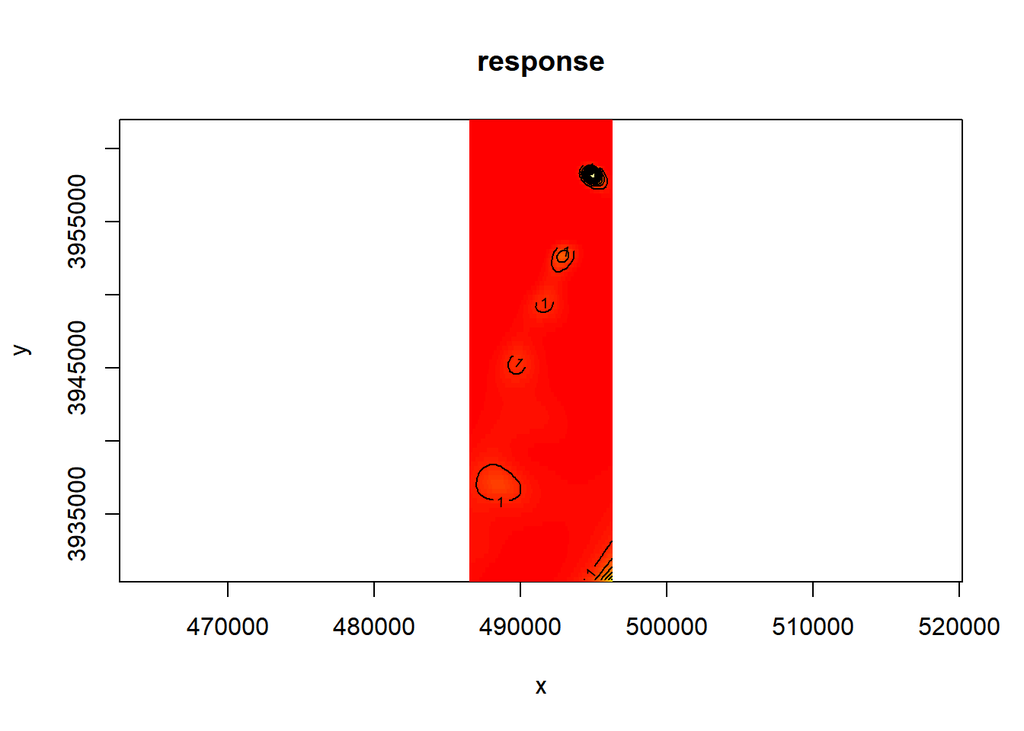

```r
vis.gam(dsm.xy, plot.type="contour", view=c("x","y"), asp=1, type="response", contour.col="black", n.grid=100)
```

Then more complex models with elevation

```r
dsm.xy.elevation <- dsm(count~s(x,y,k=10) + s(elevation_mean,k=20), detfc.hr.null, segdata, obsdata, group = TRUE, segment.area = "area", method="REML")
summary(dsm.xy.elevation)
```

```
##
## Family: quasipoisson
## Link function: log
##
## Formula:
## count ~ s(x, y, k = 10) + s(elevation_mean, k = 20) + offset(off.set)
##
## Parametric coefficients:
##             Estimate Std. Error t value Pr(>|t|)
## (Intercept)  -8.1215     0.8189  -9.918   <2e-16 ***
## ---
## Signif. codes:  0 '***' 0.001 '**' 0.01 '*' 0.05 '.' 0.1 ' ' 1
##
## Approximate significance of smooth terms:
##                      edf Ref.df      F  p-value
## s(x,y)             8.884  8.992 18.842  < 2e-16 ***
## s(elevation_mean) 11.338 13.478  6.954 7.14e-14 ***
## ---
## Signif. codes:  0 '***' 0.001 '**' 0.01 '*' 0.05 '.' 0.1 ' ' 1
##
## R-sq.(adj) =  0.0177   Deviance explained = 19.7%
## -REML = 5745.5  Scale est. = 3.9319    n = 7760
```

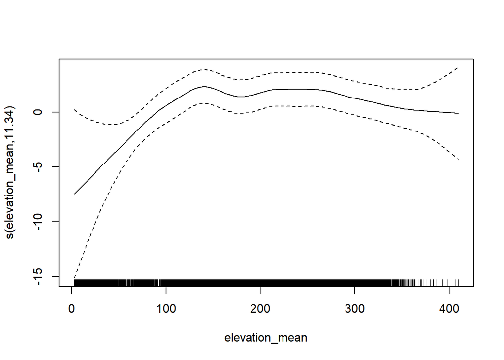

```r
plot(dsm.xy.elevation, select=2)
```

and elevation and slope

```r
dsm.xy.ele.slope <- dsm(count~s(x,y,k=10) + s(elevation_mean,k=20) +s(slope_mean, k=20), detfc.hr.null, segdata, obsdata, group = TRUE, segment.area = "area", method="REML")
summary(dsm.xy.ele.slope)
```

```
##
## Family: quasipoisson
## Link function: log
##
## Formula:
## count ~ s(x, y, k = 10) + s(elevation_mean, k = 20) + s(slope_mean,
##     k = 20) + offset(off.set)
##
## Parametric coefficients:
##             Estimate Std. Error t value Pr(>|t|)
## (Intercept)  -8.3818     0.7909   -10.6   <2e-16 ***
## ---
## Signif. codes:  0 '***' 0.001 '**' 0.01 '*' 0.05 '.' 0.1 ' ' 1
##
## Approximate significance of smooth terms:
##                      edf Ref.df      F p-value
## s(x,y)             8.885  8.992 21.210  <2e-16 ***
## s(elevation_mean) 11.586 13.688  8.734  <2e-16 ***
## s(slope_mean)     14.710 16.695  7.746  <2e-16 ***
## ---
## Signif. codes:  0 '***' 0.001 '**' 0.01 '*' 0.05 '.' 0.1 ' ' 1
##
## R-sq.(adj) =  0.0243   Deviance explained =   23%
## -REML = 5618.5  Scale est. = 3.2237    n = 7760
```

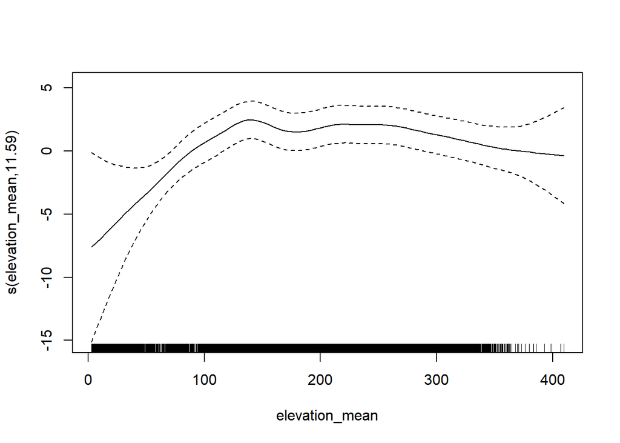

```r
plot(dsm.xy.ele.slope, select=c(2,3))
```

[output not shown]

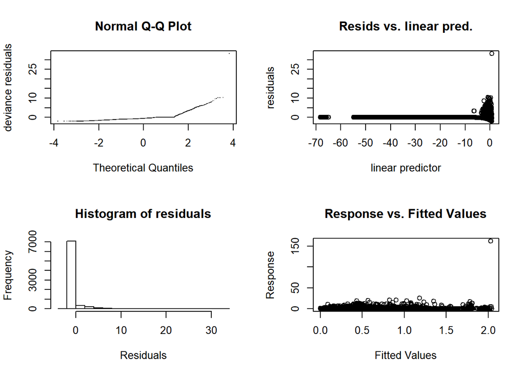

```
##
## Method: REML   Optimizer: outer newton
## full convergence after 7 iterations.
## Gradient range [-7.079386e-05,7.859685e-06]
## (score 5691.652 & scale 5.971772).
## Hessian positive definite, eigenvalue range [6.699672,3878.539].
## Model rank =  30 / 30
##
## Basis dimension (k) checking results. Low p-value (k-index<1) may
## indicate that k is too low, especially if edf is close to k'.
##
##        k' edf k-index p-value
## s(x,y) 29  28    0.74  <2e-16 ***
## ---
## Signif. codes:  0 '***' 0.001 '**' 0.01 '*' 0.05 '.' 0.1 ' ' 1
```

```r
gam.check(dsm.xy)
```

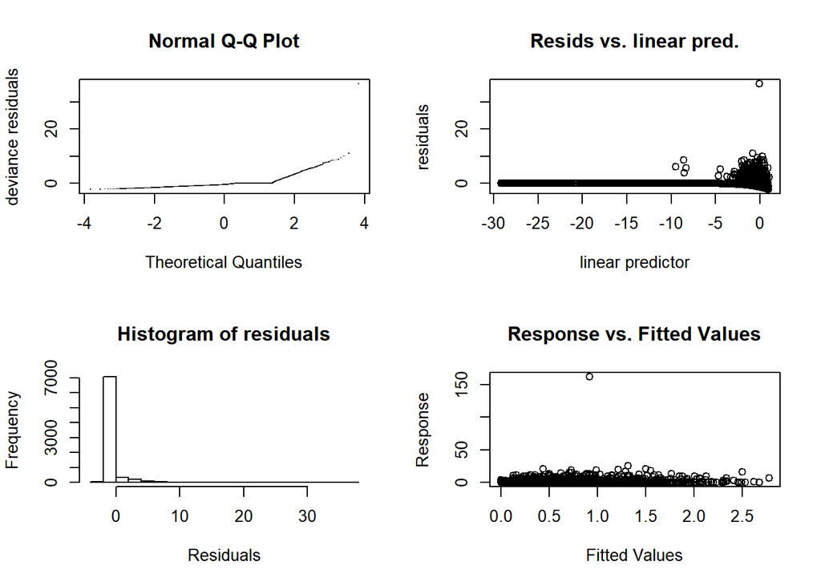

```
##
## Method: REML   Optimizer: outer newton
## full convergence after 7 iterations.
## Gradient range [-0.0005472172,0.0004115908]
## (score 5618.545 & scale 3.223674).
## Hessian positive definite, eigenvalue range [3.011077,3877.522].
## Model rank =  48 / 48
##
## Basis dimension (k) checking results. Low p-value (k-index<1) may
## indicate that k is too low, especially if edf is close to k'.
##
##                      k'   edf k-index p-value
## s(x,y)             9.00  8.88    0.74  <2e-16 ***
## s(elevation_mean) 19.00 11.59    0.92    0.22
## s(slope_mean)     19.00 14.71    0.90    0.02 *
## ---
## Signif. codes:  0 '***' 0.001 '**' 0.01 '*' 0.05 '.' 0.1 ' ' 1
```

```r
gam.check(dsm.xy.ele.slope)
```

The next stage will be to make predictions from this data.